# Kmeans clustering en R

Un Enfoque Práctico para Aprendizaje No Supervisado

Nicolás Sidicaro

2025-06-09

# K-Means Clustering en R: Guía Práctica Completa

*Basado en “An Introduction to Statistical Learning” - Capítulo 10*

## Introducción

El **clustering K-means** es uno de los algoritmos de aprendizaje no supervisado más utilizados en data science. En este notebook exploraremos tanto la teoría como la implementación práctica en R, siguiendo las mejores prácticas del campo.

## 1. Preparación del Entorno

Primero cargaremos las librerías necesarias para nuestro análisis:

```r
# Cargar librerías esenciales
library(tidyverse)      # Para manipulación y visualización de datos
library(cluster)        # Para análisis de clustering
library(factoextra)     # Para visualización avanzada de clustering
library(gridExtra)      # Para organizar múltiples gráficos
library(ggplot2)        # Para gráficos elegantes
library(NbClust)        # Para métodos de selección de K
library(fpc)            # Para estadísticas de clustering

# Configurar tema para gráficos
theme_set(theme_minimal() +
          theme(plot.title = element_text(hjust = 0.5, size = 14, face = "bold")))

# Fijar semilla para reproducibilidad
set.seed(123)
```

## 2. Generación de Datos Sintéticos

Comenzaremos con un ejemplo simple usando datos sintéticos para entender el comportamiento del algoritmo:

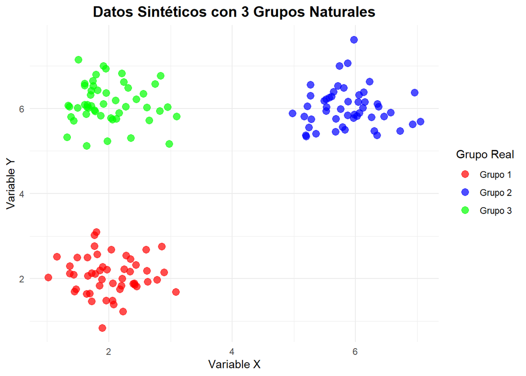

```r
# Crear datos sintéticos con 3 grupos naturales
n <- 150  # número total de puntos

# Grupo 1: centrado en (2, 2)
grupo1 <- data.frame(
  x = rnorm(50, mean = 2, sd = 0.5),
  y = rnorm(50, mean = 2, sd = 0.5),
  grupo_real = "Grupo 1"
)

# Grupo 2: centrado en (6, 6)
grupo2 <- data.frame(
  x = rnorm(50, mean = 6, sd = 0.5),
  y = rnorm(50, mean = 6, sd = 0.5),
  grupo_real = "Grupo 2"
)

# Grupo 3: centrado en (2, 6)
grupo3 <- data.frame(
  x = rnorm(50, mean = 2, sd = 0.5),
  y = rnorm(50, mean = 6, sd = 0.5),
  grupo_real = "Grupo 3"
)

# Combinar todos los datos
datos_sinteticos <- rbind(grupo1, grupo2, grupo3)

# Visualizar los datos originales
ggplot(datos_sinteticos, aes(x = x, y = y, color = grupo_real)) +
  geom_point(size = 3, alpha = 0.7) +
  labs(title = "Datos Sintéticos con 3 Grupos Naturales",
       x = "Variable X", y = "Variable Y",
       color = "Grupo Real") +
  scale_color_manual(values = c("red", "blue", "green"))
```

## 3. Implementación Básica de K-Means

Ahora aplicaremos K-means a nuestros datos sintéticos:

```r
# Preparar datos para clustering (solo variables numéricas)
datos_numericos <- datos_sinteticos[, c("x", "y")]

# Aplicar K-means con K=3 (sabemos que hay 3 grupos)
kmeans_resultado <- kmeans(datos_numericos, centers = 3, nstart = 25)

# Examinar la estructura del resultado
print("Información del clustering:")
```

```
## [1] "Información del clustering:"
```

```r
print(kmeans_resultado)
```

```
## K-means clustering with 3 clusters of sizes 50, 50, 50
##
## Cluster means:
##          x        y
## 1 1.995740 6.124725
## 2 5.873050 6.019403
## 3 2.017202 2.073204
##
## Clustering vector:
##   [1] 3 3 3 3 3 3 3 3 3 3 3 3 3 3 3 3 3 3 3 3 3 3 3 3 3 3 3 3 3 3 3 3 3 3 3 3 3
##  [38] 3 3 3 3 3 3 3 3 3 3 3 3 3 2 2 2 2 2 2 2 2 2 2 2 2 2 2 2 2 2 2 2 2 2 2 2 2
##  [75] 2 2 2 2 2 2 2 2 2 2 2 2 2 2 2 2 2 2 2 2 2 2 2 2 2 2 1 1 1 1 1 1 1 1 1 1 1
## [112] 1 1 1 1 1 1 1 1 1 1 1 1 1 1 1 1 1 1 1 1 1 1 1 1 1 1 1 1 1 1 1 1 1 1 1 1 1
## [149] 1 1
##
## Within cluster sum of squares by cluster:
## [1] 21.91525 22.60733 20.54411
##  (between_SS / total_SS =  94.1 %)
##
## Available components:
##
## [1] "cluster"      "centers"      "totss"        "withinss"     "tot.withinss"
## [6] "betweenss"    "size"         "iter"         "ifault"
```

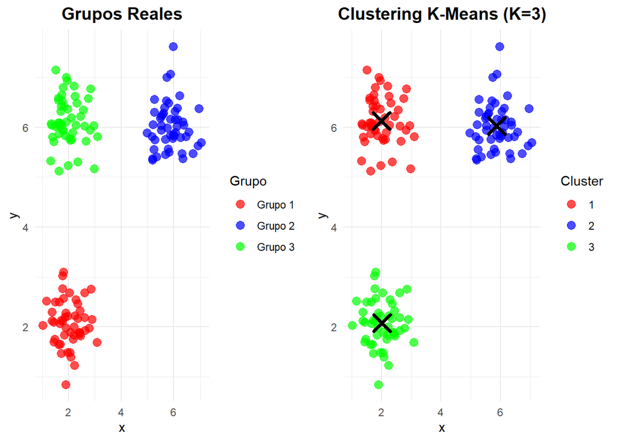

```r
# Agregar las asignaciones de cluster a nuestros datos
datos_sinteticos$cluster_kmeans <- as.factor(kmeans_resultado$cluster)

# Visualizar resultados
p1 <- ggplot(datos_sinteticos, aes(x = x, y = y, color = grupo_real)) +
  geom_point(size = 3, alpha = 0.7) +
  labs(title = "Grupos Reales", color = "Grupo") +
  scale_color_manual(values = c("red", "blue", "green"))

p2 <- ggplot(datos_sinteticos, aes(x = x, y = y, color = cluster_kmeans)) +
  geom_point(size = 3, alpha = 0.7) +
  geom_point(data = as.data.frame(kmeans_resultado$centers),
             aes(x = x, y = y), color = "black", size = 5, shape = 4, stroke = 2) +
  labs(title = "Clustering K-Means (K=3)", color = "Cluster") +
  scale_color_manual(values = c("red", "blue", "green"))

grid.arrange(p1, p2, ncol = 2)
```

### Interpretación de Resultados

El algoritmo K-means nos proporciona información valiosa:

```r
cat("Número de puntos en cada cluster:\n")
```

```
## Número de puntos en cada cluster:
```

```r
print(table(kmeans_resultado$cluster))
```

```
##
##  1  2  3
## 50 50 50
```

```r
cat("\nCentroides de cada cluster:\n")
```

```
##
## Centroides de cada cluster:
```

```r
print(kmeans_resultado$centers)
```

```
##          x        y
## 1 1.995740 6.124725
## 2 5.873050 6.019403
## 3 2.017202 2.073204
```

```r
cat("\nInercia total (sum of squares within clusters):\n")
```

```
##
## Inercia total (sum of squares within clusters):
```

```r
print(kmeans_resultado$tot.withinss)
```

```
## [1] 65.06668
```

```r
cat("\nPorcentaje de variabilidad explicada:\n")
```

```
##
## Porcentaje de variabilidad explicada:
```

```r
variabilidad_explicada <- (kmeans_resultado$betweenss / kmeans_resultado$totss) * 100
print(paste0(round(variabilidad_explicada, 2), "%"))
```

```
## [1] "94.07%"
```

## 4. Método del Codo (Elbow Method)

¿Pero qué pasa si no conocemos el número óptimo de clusters? Implementemos el método del codo:

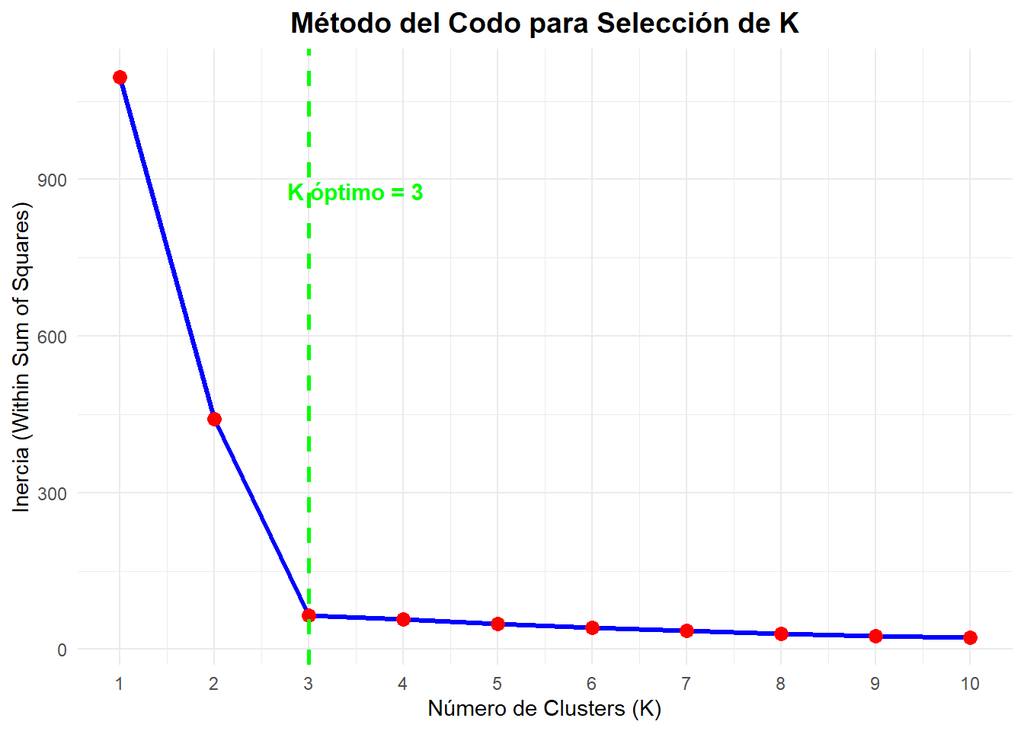

```r
# Función para calcular la inercia para diferentes valores de K
calcular_inercia <- function(datos, max_k = 10) {
  inercias <- numeric(max_k)

  for (k in 1:max_k) {
    kmeans_temp <- kmeans(datos, centers = k, nstart = 25)
    inercias[k] <- kmeans_temp$tot.withinss
  }

  return(data.frame(
    K = 1:max_k,
    Inercia = inercias
  ))
}

# Calcular inercias para K de 1 a 10
resultados_codo <- calcular_inercia(datos_numericos, max_k = 10)

# Visualizar el método del codo
ggplot(resultados_codo, aes(x = K, y = Inercia)) +
  geom_line(size = 1.2, color = "blue") +
  geom_point(size = 3, color = "red") +
  geom_vline(xintercept = 3, linetype = "dashed", color = "green", size = 1) +
  labs(title = "Método del Codo para Selección de K",
       x = "Número de Clusters (K)",
       y = "Inercia (Within Sum of Squares)") +
  annotate("text", x = 3.5, y = max(resultados_codo$Inercia) * 0.8,
           label = "K óptimo = 3", color = "green", size = 4, fontface = "bold") +
  scale_x_continuous(breaks = 1:10)
```

```r
print(resultados_codo)
```

```
##     K    Inercia
## 1   1 1096.73274
## 2   2  441.18233
## 3   3   65.06668
## 4   4   56.91497
## 5   5   49.19400
## 6   6   41.23910
## 7   7   35.46965
## 8   8   29.82664
## 9   9   24.87969
## 10 10   23.05886
```

## 5. Análisis Silhouette

Implementemos también el análisis de Silhouette para confirmar nuestro K óptimo:

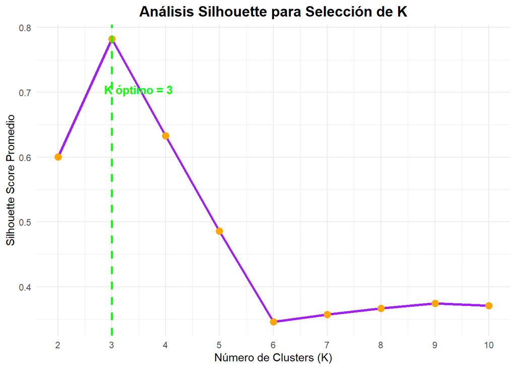

```r
# Función para calcular Silhouette Score para diferentes K
calcular_silhouette <- function(datos, max_k = 10) {
  silhouette_scores <- numeric(max_k - 1)  # No se puede calcular para K=1

  for (k in 2:max_k) {
    kmeans_temp <- kmeans(datos, centers = k, nstart = 25)
    sil_score <- cluster::silhouette(kmeans_temp$cluster, dist(datos))
    silhouette_scores[k-1] <- mean(sil_score[, "sil_width"])
  }

  return(data.frame(
    K = 2:max_k,
    Silhouette_Score = silhouette_scores
  ))
}

# Calcular Silhouette scores
resultados_silhouette <- calcular_silhouette(datos_numericos, max_k = 10)

# Visualizar resultados
ggplot(resultados_silhouette, aes(x = K, y = Silhouette_Score)) +
  geom_line(size = 1.2, color = "purple") +
  geom_point(size = 3, color = "orange") +
  geom_vline(xintercept = which.max(resultados_silhouette$Silhouette_Score) + 1,
             linetype = "dashed", color = "green", size = 1) +
  labs(title = "Análisis Silhouette para Selección de K",
       x = "Número de Clusters (K)",
       y = "Silhouette Score Promedio") +
  annotate("text", x = which.max(resultados_silhouette$Silhouette_Score) + 1.5,
           y = max(resultados_silhouette$Silhouette_Score) * 0.9,
           label = paste("K óptimo =", which.max(resultados_silhouette$Silhouette_Score) + 1),
           color = "green", size = 4, fontface = "bold") +
  scale_x_continuous(breaks = 2:10)
```

```r
print(resultados_silhouette)
```

```
##    K Silhouette_Score
## 1  2        0.6005693
## 2  3        0.7826000
## 3  4        0.6328398
## 4  5        0.4860016
## 5  6        0.3461647
## 6  7        0.3571377
## 7  8        0.3666057
## 8  9        0.3745212
## 9 10        0.3710116
```

### Comparación de Métodos

```r
# Encontrar K óptimo según cada método
k_codo <- 3  # Visualmente identificado del gráfico del codo
k_silhouette <- which.max(resultados_silhouette$Silhouette_Score) + 1

cat("Comparación de métodos para seleccionar K:\n")
```

```
## Comparación de métodos para seleccionar K:
```

```r
cat(paste("Método del Codo:", k_codo, "\n"))
```

```
## Método del Codo: 3
```

```r
cat(paste("Silhouette Score:", k_silhouette, "\n"))
```

```
## Silhouette Score: 3
```

```r
if (k_codo == k_silhouette) {
  cat("¡Ambos métodos coinciden! K óptimo =", k_codo, "\n")
} else {
  cat("Los métodos difieren. Se recomienda analizar más profundamente.\n")
}
```

```
## ¡Ambos métodos coinciden! K óptimo = 3
```

## 6. Análisis Detallado del Clustering Óptimo

Analicemos en detalle el clustering con K=3:

```
##   cluster size ave.sil.width
## 1       1   50          0.78
## 2       2   50          0.80
## 3       3   50          0.77
```

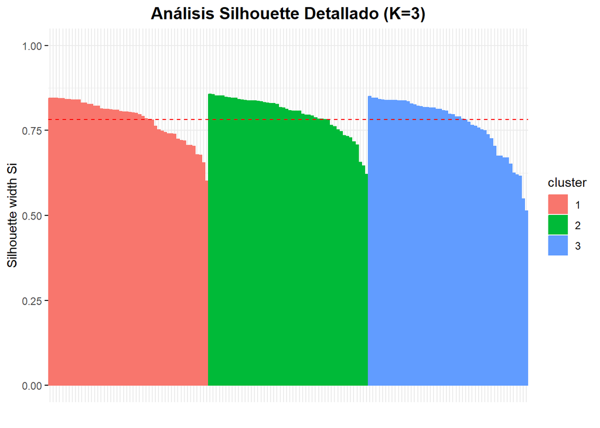

```r
# Aplicar K-means con K óptimo
kmeans_final <- kmeans(datos_numericos, centers = 3, nstart = 25)

# Calcular y visualizar el silhouette plot detallado
sil_analisis <- cluster::silhouette(kmeans_final$cluster, dist(datos_numericos))

# Crear gráfico de silhouette
fviz_silhouette(sil_analisis) +
  labs(title = "Análisis Silhouette Detallado (K=3)")
```

```r
# Estadísticas por cluster
datos_sinteticos$cluster_final <- as.factor(kmeans_final$cluster)

estadisticas_cluster <- datos_sinteticos %>%
  group_by(cluster_final) %>%
  summarise(
    n_puntos = n(),
    x_promedio = round(mean(x), 2),
    y_promedio = round(mean(y), 2),
    x_sd = round(sd(x), 2),
    y_sd = round(sd(y), 2),
    .groups = 'drop'
  )

print("Estadísticas por cluster:")
```

```
## [1] "Estadísticas por cluster:"
```

```r
print(estadisticas_cluster)
```

```
## # A tibble: 3 × 6
##   cluster_final n_puntos x_promedio y_promedio  x_sd  y_sd
##   <fct>            <int>      <dbl>      <dbl> <dbl> <dbl>
## 1 1                   50       5.87       6.02  0.49  0.47
## 2 2                   50       2.02       2.07  0.46  0.45
## 3 3                   50       2          6.12  0.47  0.47
```

## 7. Ejemplo con Datos Reales: Dataset Iris

Ahora trabajemos con un dataset real para ver cómo se comporta K-means en la práctica:

```r
# Cargar dataset iris (sin la variable Species para clustering no supervisado)
data(iris)
iris_datos <- iris[, 1:4]  # Solo variables numéricas
iris_especies_reales <- iris$Species

# Estandarizar los datos (muy importante para K-means)
iris_escalado <- scale(iris_datos)

cat("Primeras filas del dataset Iris (escalado):\n")
```

```
## Primeras filas del dataset Iris (escalado):
```

```r
print(head(iris_escalado))
```

```
##      Sepal.Length Sepal.Width Petal.Length Petal.Width
## [1,]   -0.8976739  1.01560199    -1.335752   -1.311052
## [2,]   -1.1392005 -0.13153881    -1.335752   -1.311052
## [3,]   -1.3807271  0.32731751    -1.392399   -1.311052
## [4,]   -1.5014904  0.09788935    -1.279104   -1.311052
## [5,]   -1.0184372  1.24503015    -1.335752   -1.311052
## [6,]   -0.5353840  1.93331463    -1.165809   -1.048667
```

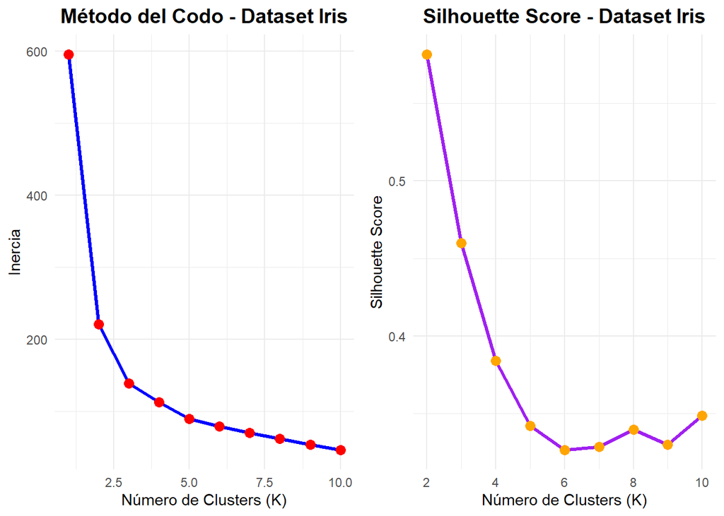

```r
# Aplicar método del codo
inercias_iris <- numeric(10)
for (k in 1:10) {
  kmeans_temp <- kmeans(iris_escalado, centers = k, nstart = 25)
  inercias_iris[k] <- kmeans_temp$tot.withinss
}

# Calcular Silhouette scores para Iris
silhouette_iris <- numeric(9)
for (k in 2:10) {
  kmeans_temp <- kmeans(iris_escalado, centers = k, nstart = 25)
  sil_score <- cluster::silhouette(kmeans_temp$cluster, dist(iris_escalado))
  silhouette_iris[k-1] <- mean(sil_score[, "sil_width"])
}

# Crear gráficos de selección de K para Iris
p1_iris <- ggplot(data.frame(K = 1:10, Inercia = inercias_iris),
                  aes(x = K, y = Inercia)) +
  geom_line(size = 1.2, color = "blue") +
  geom_point(size = 3, color = "red") +
  labs(title = "Método del Codo - Dataset Iris",
       x = "Número de Clusters (K)", y = "Inercia")

p2_iris <- ggplot(data.frame(K = 2:10, Silhouette = silhouette_iris),
                  aes(x = K, y = Silhouette)) +
  geom_line(size = 1.2, color = "purple") +
  geom_point(size = 3, color = "orange") +
  labs(title = "Silhouette Score - Dataset Iris",
       x = "Número de Clusters (K)", y = "Silhouette Score")

grid.arrange(p1_iris, p2_iris, ncol = 2)
```

### Aplicar K-means al Dataset Iris

```r
# Aplicar K-means con K=3 (sabemos que hay 3 especies)
kmeans_iris <- kmeans(iris_escalado, centers = 3, nstart = 25)

# Crear dataframe para análisis
iris_resultados <- data.frame(
  iris_datos,
  Especie_Real = iris_especies_reales,
  Cluster_KMeans = as.factor(kmeans_iris$cluster)
)

# Tabla de confusión
tabla_confusion <- table(iris_resultados$Especie_Real, iris_resultados$Cluster_KMeans)
print("Tabla de Confusión (Especies vs Clusters):")
```

```
## [1] "Tabla de Confusión (Especies vs Clusters):"
```

```r
print(tabla_confusion)
```

```
##
##               1  2  3
##   setosa      0  0 50
##   versicolor 39 11  0
##   virginica  14 36  0
```

```r
# Calcular precisión
precision <- sum(diag(tabla_confusion)) / sum(tabla_confusion)
cat(paste("\nPrecisión del clustering:", round(precision * 100, 2), "%\n"))
```

```
##
## Precisión del clustering: 7.33 %
```

### Visualización Multidimensional

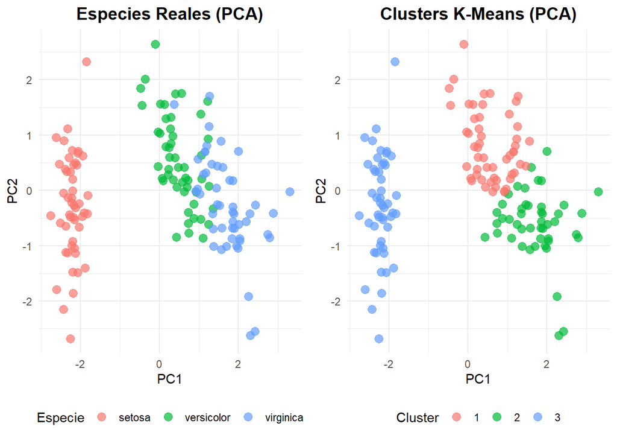

```r
# Realizar PCA para visualización en 2D
pca_iris <- prcomp(iris_escalado, center = FALSE, scale. = FALSE)

# Crear dataframe con componentes principales
iris_pca <- data.frame(
  PC1 = pca_iris$x[, 1],
  PC2 = pca_iris$x[, 2],
  Especie_Real = iris_especies_reales,
  Cluster_KMeans = as.factor(kmeans_iris$cluster)
)

# Gráficos comparativos
p1_pca <- ggplot(iris_pca, aes(x = PC1, y = PC2, color = Especie_Real)) +
  geom_point(size = 3, alpha = 0.7) +
  labs(title = "Especies Reales (PCA)", color = "Especie") +
  theme(legend.position = "bottom")

p2_pca <- ggplot(iris_pca, aes(x = PC1, y = PC2, color = Cluster_KMeans)) +
  geom_point(size = 3, alpha = 0.7) +
  labs(title = "Clusters K-Means (PCA)", color = "Cluster") +
  theme(legend.position = "bottom")

grid.arrange(p1_pca, p2_pca, ncol = 2)
```

```r
# Mostrar la varianza explicada por cada componente principal
cat("Varianza explicada por cada componente principal:\n")
```

```
## Varianza explicada por cada componente principal:
```

```r
print(summary(pca_iris))
```

```
## Importance of components:
##                           PC1    PC2     PC3     PC4
## Standard deviation     1.7084 0.9560 0.38309 0.14393
## Proportion of Variance 0.7296 0.2285 0.03669 0.00518
## Cumulative Proportion  0.7296 0.9581 0.99482 1.00000
```

## 8. Diagnóstico y Validación del Clustering

Evaluemos la calidad de nuestro clustering con diferentes métricas:

```r
# Usar la librería factoextra para análisis más avanzado
library(factoextra)

# Calcular múltiples métricas de validación
cat("=== MÉTRICAS DE VALIDACIÓN ===\n\n")
```

```
## === MÉTRICAS DE VALIDACIÓN ===
```

```r
# 1. Silhouette Score promedio
sil_iris <- cluster::silhouette(kmeans_iris$cluster, dist(iris_escalado))
cat("1. Silhouette Score promedio:", round(mean(sil_iris[, "sil_width"]), 3), "\n")
```

```
## 1. Silhouette Score promedio: 0.46
```

```r
# 2. Calinski-Harabasz Index
ch_index <- cluster.stats(dist(iris_escalado), kmeans_iris$cluster)$ch
cat("2. Calinski-Harabasz Index:", round(ch_index, 2), "\n")
```

```
## 2. Calinski-Harabasz Index: 241.9
```

```r
# 3. Davies-Bouldin Index
db_index <- cluster.stats(dist(iris_escalado), kmeans_iris$cluster)$dunn
cat("3. Dunn Index:", round(db_index, 3), "\n")
```

```
## 3. Dunn Index: 0.026
```

```r
# 4. Within Sum of Squares
cat("4. Within Sum of Squares:", round(kmeans_iris$tot.withinss, 2), "\n")
```

```
## 4. Within Sum of Squares: 138.89
```

```r
# 5. Between Sum of Squares / Total Sum of Squares
bss_tss_ratio <- kmeans_iris$betweenss / kmeans_iris$totss
cat("5. BSS/TSS ratio:", round(bss_tss_ratio, 3), "\n")
```

```
## 5. BSS/TSS ratio: 0.767
```

```
##   cluster size ave.sil.width
## 1       1   53          0.39
## 2       2   47          0.35
## 3       3   50          0.64
```

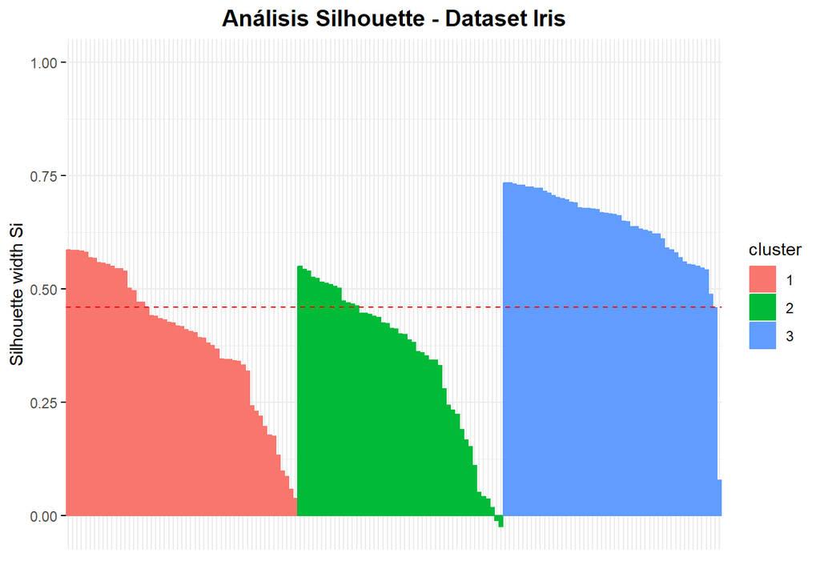

```r
# Visualización del silhouette plot
fviz_silhouette(sil_iris) +
  labs(title = "Análisis Silhouette - Dataset Iris")
```

## 9. Comparación con Clustering Jerárquico

Comparemos nuestros resultados con clustering jerárquico:

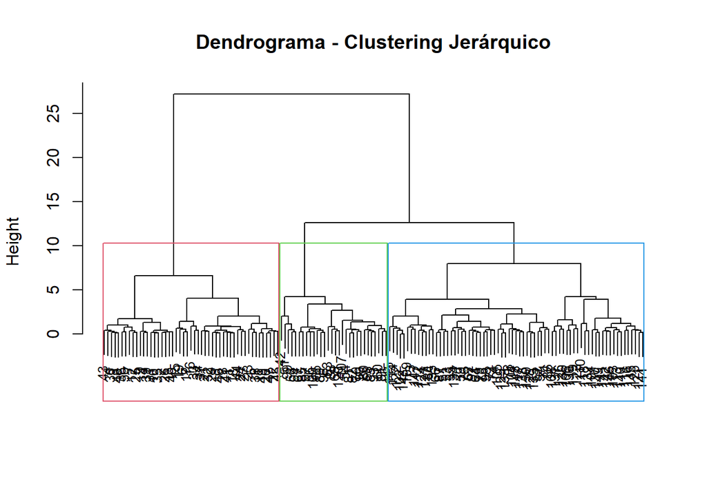

```r
# Clustering jerárquico
dist_matrix <- dist(iris_escalado)
hc_ward <- hclust(dist_matrix, method = "ward.D2")

# Cortar el dendrograma para obtener 3 clusters
clusters_jerarquico <- cutree(hc_ward, k = 3)

# Crear dendrograma
plot(hc_ward, main = "Dendrograma - Clustering Jerárquico",
     xlab = "", sub = "", cex = 0.8)
rect.hclust(hc_ward, k = 3, border = 2:4)
```

```r
# Comparar resultados
comparacion <- data.frame(
  Especie_Real = iris_especies_reales,
  KMeans = kmeans_iris$cluster,
  Jerarquico = clusters_jerarquico
)

cat("Comparación de métodos de clustering:\n")
```

```
## Comparación de métodos de clustering:
```

```r
cat("Correlación K-Means vs Jerárquico:",
    round(cor(kmeans_iris$cluster, clusters_jerarquico), 3), "\n")
```

```
## Correlación K-Means vs Jerárquico: -0.662
```

```r
# Tabla de contingencia
print("Tabla de contingencia K-Means vs Jerárquico:")
```

```
## [1] "Tabla de contingencia K-Means vs Jerárquico:"
```

```r
print(table(kmeans_iris$cluster, clusters_jerarquico))
```

```
##    clusters_jerarquico
##      1  2  3
##   1  0 29 24
##   2  0  0 47
##   3 49  1  0
```

## 10. Buenas Prácticas y Recomendaciones

### Checklist para K-Means Exitoso:

```r
# ✅ ANTES DE APLICAR K-MEANS:

# 1. Explorar y limpiar los datos
summary(datos)
plot(datos)

# 2. Estandarizar/escalar variables
datos_escalados <- scale(datos)

# 3. Remover outliers si es necesario
# Métodos: boxplots, z-scores, análisis visual

# 4. Verificar correlaciones altas entre variables
cor(datos)

# ✅ DURANTE EL ANÁLISIS:

# 1. Usar múltiples inicializaciones
kmeans(datos, centers = k, nstart = 25)

# 2. Probar diferentes valores de K
# Usar método del codo Y silhouette score

# 3. Validar con múltiples métricas
# Silhouette, Calinski-Harabasz, Davies-Bouldin

# ✅ DESPUÉS DEL CLUSTERING:

# 1. Interpretar los centroides
print(modelo$centers)

# 2. Analizar la composición de cada cluster
table(clusters, variable_categorica)

# 3. Visualizar resultados
# PCA, t-SNE para alta dimensionalidad

# 4. Validar con conocimiento del dominio
```

### Cuándo NO usar K-Means:

```r
# ❌ NO usar K-Means cuando:

# 1. Los clusters no son esféricos
# Alternativa: DBSCAN, clustering jerárquico

# 2. Los clusters tienen densidades muy diferentes
# Alternativa: Gaussian Mixture Models

# 3. Hay mucho ruido/outliers
# Alternativa: DBSCAN, clustering robusto

# 4. Los clusters tienen tamaños muy diferentes
# Alternativa: clustering basado en densidad

# 5. Las variables tienen escalas muy diferentes y no se pueden estandarizar
# Alternativa: métodos que manejan variables categóricas
```

## 11. Ejercicio Práctico

Te propongo un ejercicio para consolidar el aprendizaje:

```r
# EJERCICIO: Analizar el dataset mtcars
data(mtcars)

# Tareas:
# 1. Explora el dataset mtcars
# 2. Selecciona variables relevantes para clustering
# 3. Escala los datos apropiadamente
# 4. Aplica el método del codo y silhouette analysis
# 5. Ejecuta K-means con el K óptimo
# 6. Interpreta los clusters obtenidos
# 7. ¿Qué tipos de autos agrupa cada cluster?

# Código de inicio:
head(mtcars)
# Tu código aquí...
```

## 12. Conclusiones

### Puntos Clave del K-Means:

1. **Simplicidad y Eficiencia**: K-means es rápido y fácil de implementar
2. **Preparación de Datos**: El escalado es crucial para buenos resultados
3. **Selección de K**: Combinar método del codo con silhouette score
4. **Validación**: Usar múltiples métricas para evaluar calidad
5. **Interpretación**: Los centroides son clave para entender los clusters
6. **Limitaciones**: Asume clusters esféricos y de tamaño similar

### Próximos Pasos:

- Explorar clustering jerárquico
- Aprender DBSCAN para clusters de forma irregular
- Estudiar Gaussian Mixture Models
- Aplicar técnicas de reducción de dimensionalidad (PCA, t-SNE)

## Referencias

- James, G., Witten, D., Hastie, T., & Tibshirani, R. (2013). *An Introduction to Statistical Learning*. Springer.
- Kassambara, A. (2017). *Practical Guide to Cluster Analysis in R*. STHDA.
- Documentación de R: `?kmeans`, `?cluster`, `?factoextra`

*Notebook creado para el aprendizaje de K-Means clustering en R*  
*Fecha: Junio 2025*